# Progress Memo 2

Final Project  
Data Science 1 with R (STAT 301-1)

Author

Sonia Bhatia

Published

December 5, 2023

**Github Repo Link**

My github link is below.

https://github.com/stat301-1-2023-fall/final-project-1-soniab101

**Link to kaggle dataset (citation)**

[World Cups and World Cup Matches datasets](https://www.kaggle.com/datasets/abecklas/fifa-world-cup?select=WorldCups.csv)

## Introduction

These datasets about the Fifa World Cup are interesting to me since I enjoy watching soccer matches, especially the world cup. One dataset contains overall information on the World Cup held every four years, and the other contains specific information about each match held in each World Cup. I believe there are many conclusions that can be drawn from this data, and many interesting questions that can be explored. Some questions I am interested in investigating are if there is any correlation between a team playing a match in their home country and whether that gives them an advantage in winning or not. I am also interested in the differences between viewership of matches.

## Data Overview & Quality

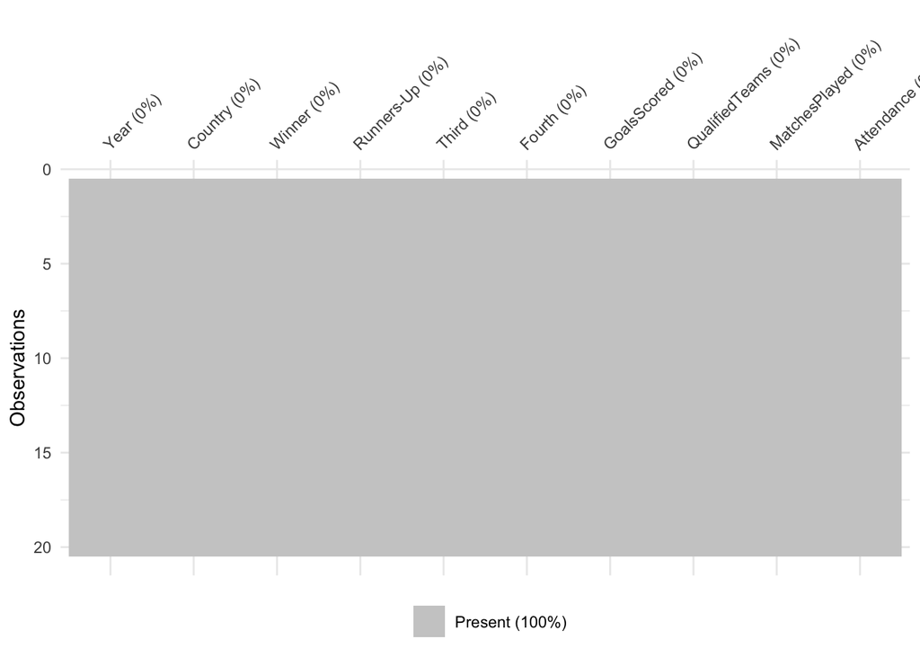

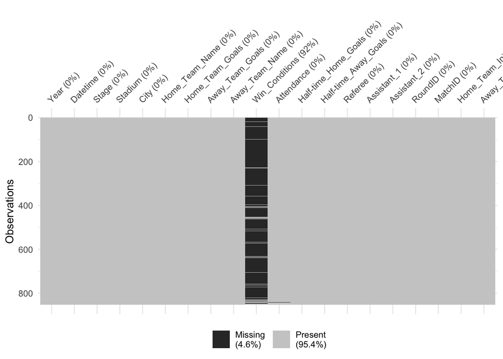

## Summary of the datasets

Summary Statistics

| Variable | N | Mean | Std. Dev. | Min | Pctl. 25 | Pctl. 75 | Max |
| --- | --- | --- | --- | --- | --- | --- | --- |
| Year | 20 | 1975 | 26 | 1930 | 1957 | 1995 | 2014 |
| GoalsScored | 20 | 119 | 33 | 70 | 89 | 145 | 171 |
| QualifiedTeams | 20 | 21 | 7.3 | 13 | 16 | 26 | 32 |
| MatchesPlayed | 20 | 42 | 17 | 17 | 30 | 55 | 64 |
| Attendance | 20 | 1872882 | 1071842 | 363000 | 874832 | 2725173 | 3587538 |

Summary Statistics

| Variable | N | Mean | Std. Dev. | Min | Pctl. 25 | Pctl. 75 | Max |
| --- | --- | --- | --- | --- | --- | --- | --- |
| Year | 852 | 1985 | 22 | 1930 | 1970 | 2002 | 2014 |
| Home_Team_Goals | 852 | 1.8 | 1.6 | 0 | 1 | 3 | 10 |
| Away_Team_Goals | 852 | 1 | 1.1 | 0 | 0 | 2 | 7 |
| Attendance | 850 | 45165 | 23485 | 2000 | 30000 | 61374 | 173850 |

# Data Cleaning

I noticed that the team name Germany was coded both as Germany and also Germany FR. After investigating the meaning of this, I realized that Germany FR was West Germany before the country was reunified. I decided to recode Germany FR as Germany, since that is how the country is considered today, and their overall world cup wins are measured for the country as a whole officially. Additionally, I parsed the Datetime variable in the World Cup Matches dataset, and turned it into a date object. Also, I renamed many of the variable names that contained a space in them. I needed to recode the attendance variable in the WorldCups dataset, as it was a character variable rather than a numerical one.

# Univariate Analysis

I am investigating two variables in this section: Winner, which tells us which country won the World Cup that year, and GoalsScored, which tells us the total number of goals scored that World Cup. I believe these variables are important to fully understanding the data, as they tell us a lot about the performance of different countries and how the overall performance of teams has improved over the years.

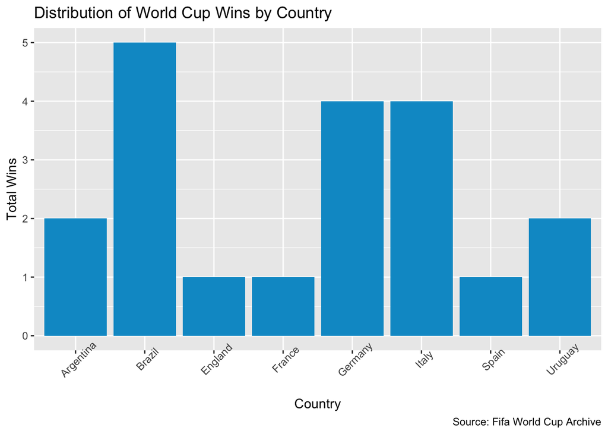

Figure 1: Information on the number of times certain countries have won the world cup

I was able to investigate the distribution of World Cup Wins through this bar plot, and see that Brazil has the highest number of wins of 5, with Germany and Italy tied at 4 wins.

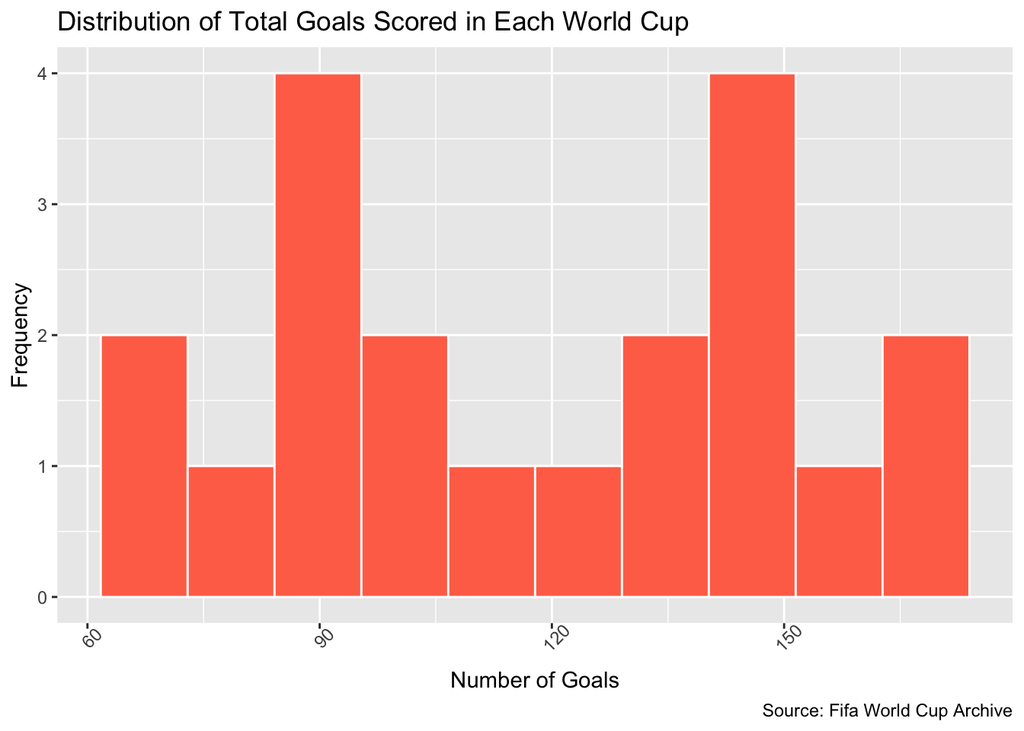

Figure 2: Information on the goals scored at the World Cup

I was able to explore the total Goals Scored per World Cup and was surprised to learn that it has a very symmetrical distribution. World Cups with goals scored between about 85-95 and 140-152 goals had the highest frequency.

# Bivariate Analysis

I am exploring the relationships between the variables years vs attendance per world cup and years vs total goals scored at that World Cup to get a better understanding of these variables. I think it is important to understand the relationship of these variables with years, as we can see how the trend has changed over time and can create hypotheses as to what is driving these trends.

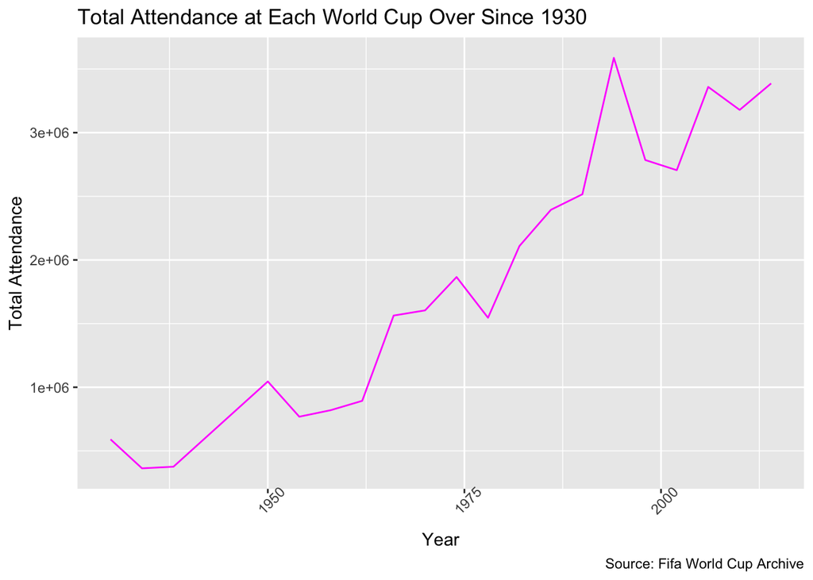

Figure 3: Information on the trend of attendance at the World Cup since 1930

I was able to see that the total attendance has greatly increased over the years since 1930, but does not always consistently increase. There is occasionally a slight decrease between years, such as between 1998 and 2002.

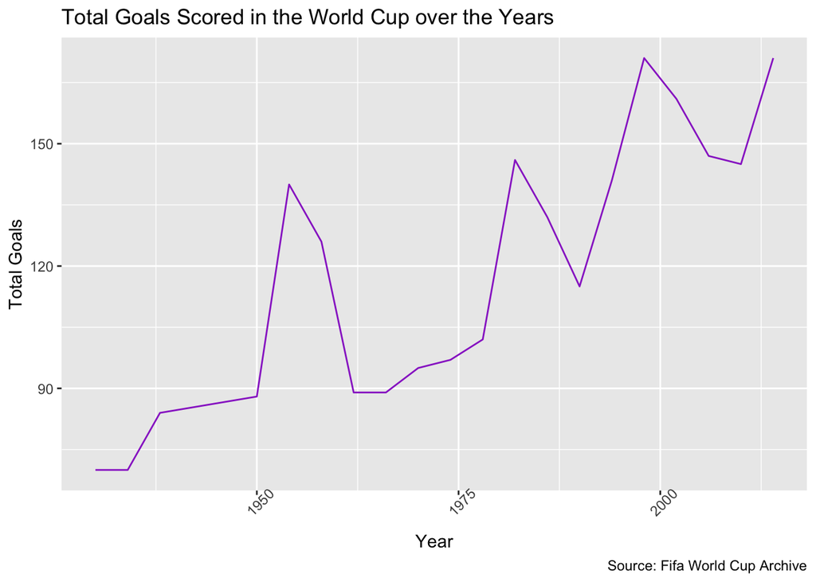

Figure 4: Information on the trend of total goals scored in the World Cup since 1930

# Progress and Conclusion

I believe I have made great progress in my exploration and analysis of this data, and have gained insights into the relationships between different variables. After investigating the data, I was able to determine which variable names and values needed cleaning, and made the data a lot more organized. Additionally, I learned more about variables such as attendance and goals scored, and how these variables have changed over time. This has helped guide me towards forming my overall research questions, which relate to learning about how the attendance of World Cup matches varies based on which country the match is held in.